# Week 7. Foundation of Inference

# Foundation of Inference

## 패키지 불러오기

```r
library(haven)
library(knitr) # R의 결과를 표로 재구성하는 데 유용한 패키지
library(kableExtra) # knitr의 표 스타일을 보조하는 패키지
library(ggplot2)
library(patchwork)
library(tidyverse)
library(futurevisions) # 그래픽 컬러 패키지
theme_set(theme_bw()) # 자동으로 ggplot 테마를 bw로 설정
```

## 들어가며

오늘 정리해볼 내용은 통계학의 핵심 중 하나인 추론(inference)의 근간이 되는 표본을 구하는 과정, 표집(sampling)을 어떻게 코딩으로 구현하는가와 관련된 것입니다. 즉, 이번 포스팅은 아래와 같은 내용을 주로 다룬다고 할 수 있습니다.

- R에서 표집 작업을 어떻게 수행하는가?
- 표집분포는 어떠한 형태를 띄는가?
- 표집분포를 어떻게 계산하는가?

이해를 돕기 위해서 사회과학 분야에서 널리 쓰는 세계발전지표(World Development Indicators, WDI)에서 변수들을 추출하여 활용해보도록 하겠습니다. 먼저 `WDI`를 라이브러리에서 로드해봅시다. 없으면 당연히 설치해야겠죠?

```r
# install.packages("WDI")
library(WDI)
```

`WDI` 데이터셋에서 우리는 동일한 국가들이 시간을 거듭해(over time) 갖는 반복적인 값을 갖는 것을 확인할 수 있습니다. 이때 반복이란 동일하다는 얘기가 아니라 미국 2000년의 경제성장률, 미국 2001년의 경제성장률과 같은 식으로 일종의 패널(panel)을 이룬다는 것을 의미합니다.

이러한 자료의 구조는 자료 내에 내재할 수 있는 시간적 흐름의 상관효과, 그리고 동시기의 국가(단위)들 간에 존재할 수 있는 상관효과 등을 고려해주어야 함을 의미합니다. 물론, 여기서는 추론과 추론에 필요한 표집을 살펴볼 것이기 때문에 더 자세한 내용까지는 들어가지 않을 것입니다.

`WDI`에서 다음과 같은 변수들을 추출해 `WDI.data`라는 데이터프레임에 저장해보겠습니다.

- 사망률 (mortality rate)
- 미국으로부터의 순 원조 유입 (net aid flows from US)
- 파상풍 예방주사 (newborns vaccinated for tetanus)
- 도시 지역 인구(전체 대비, urban pop %)
- 무역개방성 (수출입 총합 대비 GDP, trade % GDP)

```r
WDI.data <-
  WDI(country = "all",
      indicator = c("SH.DYN.NMRT",
                    "DC.DAC.USAL.CD",
                    "SH.VAC.TTNS.ZS",
                    "SP.URB.TOTL.IN.ZS",
                    "NE.TRD.GNFS.ZS"),
      start = 1990, end = 2005,
      extra = FALSE, cache = NULL)
```

그리고 간단하게 자료에서 변수들의 형태를 살펴보겠습니다.

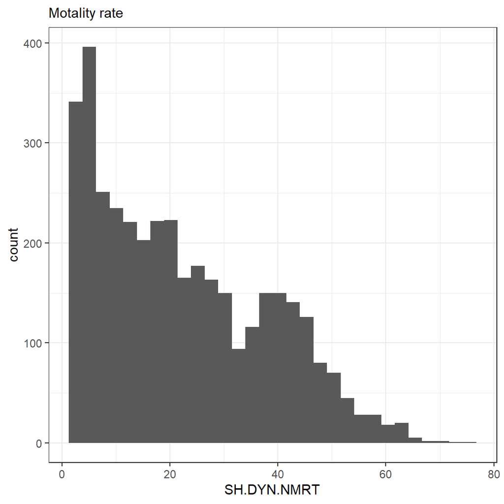

```r
## 사망률
WDI.data %>% ggplot(aes(SH.DYN.NMRT)) +
  geom_histogram() +
  labs(subtitle = "Motality rate")
```

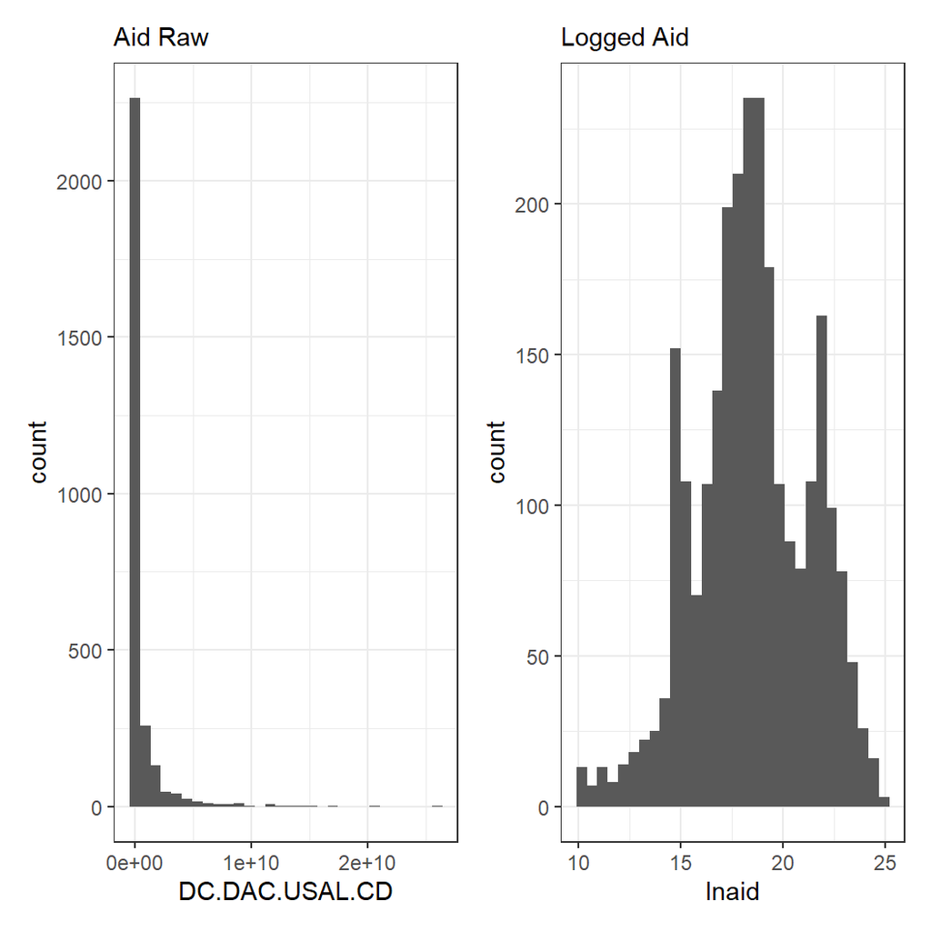

```r
## 원조
## (첫 번째는 원자료로 두 번째는 로그화한 결과)
## 먼저 순원조액에 로그값을 취한 변수를 새롭게 만들어 줍니다.
WDI.data <- WDI.data %>% mutate(
  lnaid = log(DC.DAC.USAL.CD)+1)
## 1을 더해주는 경우는 혹시나 0이 있을 경우, 그 결과가
## NA로 바뀌기 때문입니다.

## 원자료 히스토그램
raw_aid <- WDI.data %>% ggplot(aes(DC.DAC.USAL.CD)) +
  geom_histogram() + labs(subtitle= "Aid Raw")
log_aid <- WDI.data %>% ggplot(aes(lnaid)) +
  geom_histogram() + labs(subtitle= "Logged Aid")
raw_aid + log_aid + patchwork::plot_layout(ncol = 2)
```

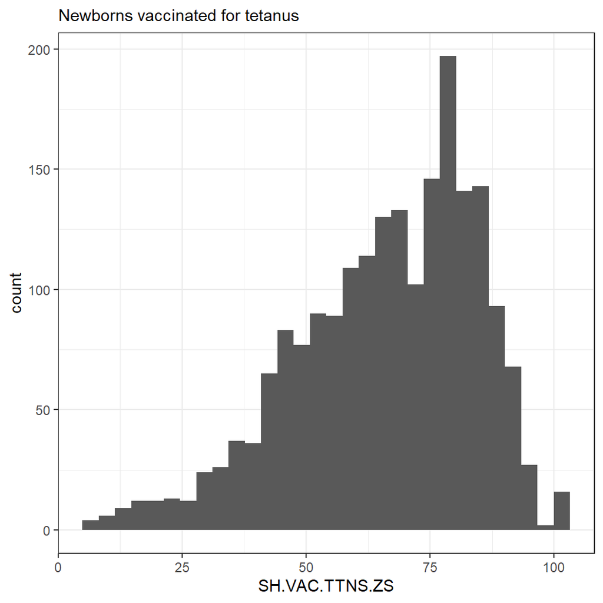

```r
## 파상풍 예방주사
WDI.data %>% ggplot(aes(SH.VAC.TTNS.ZS)) +
  geom_histogram() +
  labs(subtitle = "Newborns vaccinated for tetanus")
```

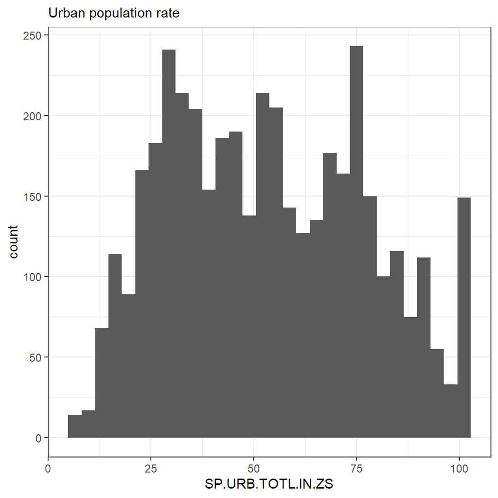

```r
## 도시 인구
WDI.data %>% ggplot(aes(SP.URB.TOTL.IN.ZS)) +
  geom_histogram() +
  labs(subtitle = "Urban population rate")
```

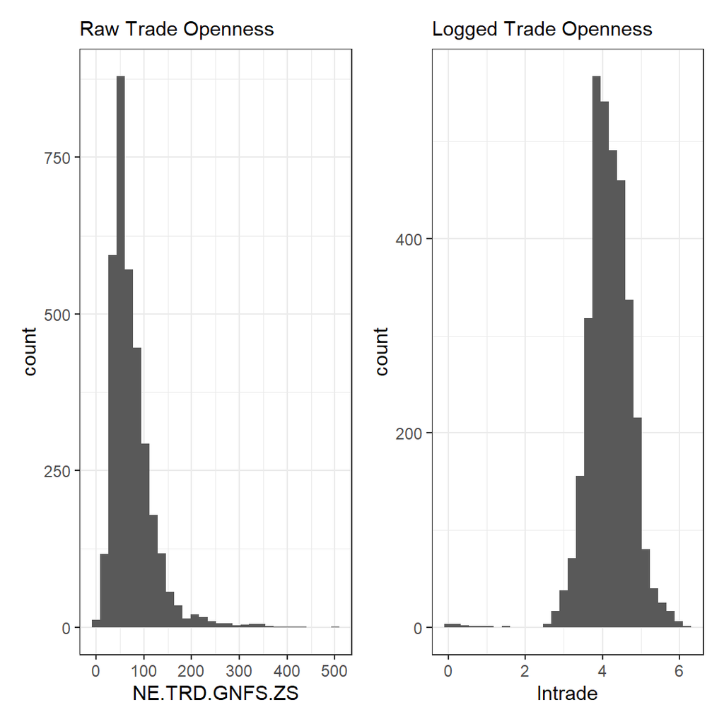

```r
# 무역개방성 (마찬가지로 원조처럼 원자료와 로그화한 자료로)
WDI.data <- WDI.data %>% mutate(
  lntrade = log(NE.TRD.GNFS.ZS + 1)
)

raw_trade <- WDI.data %>% ggplot(aes(NE.TRD.GNFS.ZS)) +
  geom_histogram() +
  labs(subtitle = "Raw Trade Openness")
ln_trade <-  WDI.data %>% ggplot(aes(lntrade)) +
  geom_histogram() +
  labs(subtitle = "Logged Trade Openness")

raw_trade + ln_trade + patchwork::plot_layout(ncol = 2)
```

## 표본을 통한 모집단 추론 (Infer Population using Samples)

이제 이 변수들의 모집단을 우리가 모른다고 가정해보겠습니다. 대신 각각의 변수들로부터 50개의 관측치들을 무작위 표본을 취한다고 생각합시다. 그리고 우리는 이 무작위 표본을 5,000번 반복하여 뽑고 그렇게 뽑힌 5,000개의 무작위 표본들의 평균 분포를 그래프로 나타내겠습니다. 우선, 사망률에 대한 무작위 표본 1개를 뽑아보고, 그 표본 이름은 `samp1.mort` 라고 해보겠습니다.

```r
samp1.mort <- sample(WDI.data$SH.DYN.NMRT, 50)
```

표본 평균과 모집단 평균을 비교해보겠습니다.

```r
mean(samp1.mort, na.rm = TRUE) # 사망률 표본의 평균
```

```
## [1] 21.35111
```

```r
## na.rm 옵션은 표본에 결측치가 있을 수 있을 때 중요하게 사용됩니다.
## 결측치 빼고 평균을 구하란 뜻입니다.
mean(WDI.data$SH.DYN.NMRT, na.rm = TRUE) # 사망률 모집단의 평균
```

```
## [1] 22.29996
```

이제 5,000개의 표본들을 루프(loop)를 가지고 뽑아서 그 각각의 평균들을 벡터로 저장해보겠습니다. 이를 위해서 먼저 빈깡통, 빈 벡터(Blank vector)를 만들어야 합니다.

```r
# 빈 벡터 만들기
sample_means50.mort <- rep(NA, 5000)
# 루프로 5,000개의 표본평균을 구해 저장하기
for(i in 1:5000) {
  samp <- sample(WDI.data$SH.DYN.NMRT, 50)
  sample_means50.mort[i] <- mean(samp, na.rm = TRUE)
}
```

여기에서 루프의 의미는 원래 우리가 가지고 있던 `WDI`의 사망률 지표에서 50개씩 꺼낸 표본을 1개라고 할 때, 이와 같은 과정을 5,000번 반복하라는 것입니다. 그러면 5,000개의 표본을 얻게 되고, 이 중 당연히 결측치도 있을 수 있으므로 `na.rm()` 옵션으로 결측치를 제외하여 평균을 구하라고 코딩하는 것입니다.

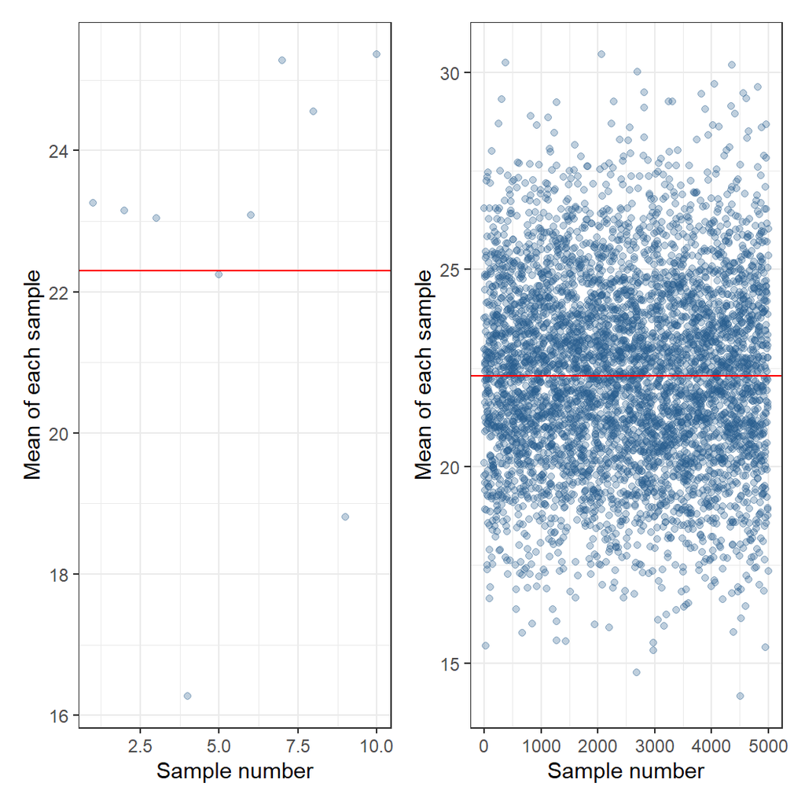

```r
## 50개의 관측치를 가지는 표본을 10번 뽑았을 때 평균의 분포
sample_means50.mort10 <- rep(NA, 10)
# 루프로 5,000개의 표본평균을 구해 저장하기
for(i in 1:10) {
  samp <- sample(WDI.data$SH.DYN.NMRT, 50)
  sample_means50.mort10[i] <- mean(samp, na.rm = TRUE)
}
sampling10 <- sample_means50.mort10 %>% as_tibble() %>%
  rowid_to_column() %>%
  ggplot(aes(x = rowid, y = value)) +
  geom_point(alpha = 0.3,
             color = futurevisions::futurevisions("mars")[3]) +
  labs(x = "Sample number", y = "Mean of each sample") +
  geom_hline(yintercept =
               mean(WDI.data$SH.DYN.NMRT, na.rm = TRUE),
             color = "red")
## 50개의 관측치를 가지는 표본을 5000번 뽑았을 때의 평균의 분포
## 표집분포 (sampling distribution)
## 이 표본들의 평균의 분포가 가지는 표준편차 = 표준오차
sampling5000 <- sample_means50.mort %>% as_tibble() %>%
  rowid_to_column() %>%
  ggplot(aes(x = rowid, y = value)) +
  geom_point(alpha = 0.3,
             color = futurevisions::futurevisions("mars")[3]) +
  labs(x = "Sample number", y = "Mean of each sample") +
  geom_hline(yintercept =
               mean(WDI.data$SH.DYN.NMRT, na.rm = TRUE),
             color = "red")
sampling10 + sampling5000 + patchwork::plot_layout(ncol = 2)
```

```r
mean(sample_means50.mort, na.rm = TRUE)
```

```
## [1] 22.33457
```

```r
mean(WDI.data$SH.DYN.NMRT, na.rm = TRUE)
```

```
## [1] 22.29996
```

이제 전체 인구 대비 도시 인구의 비율 변수를 살펴보겠습니다. 주어진 중심극한정리 (Central Limit Theorem)에 따라 우리는 오직 1개의 표본만을 취해 모집단에 대한 95%의 신뢰 구간을 계산해볼 것입니다. 이전과 마찬가지로 50개의 값을 무작위로 추출해 `samp.pop` 이라는 자료에 담고 이 표본을 이용하여 평균과 표준오차를 계산해보겠습니다.

> 신뢰구간에 대한 내용은 추후 선형회귀모델 부분에 들어가서 더 자세하게 다룰 것입니다. 일단 모집단과 표본은 결코 같을 수 없고, 그 필연적인 차이로 인해 우리는 모집단을 확인하는 것이 아니라 표본을 통해서 모집단이 어떠할 것이라고 추론할 수밖에 없으며, 이때 모집단의 특성을 추론한 결과의 불확실성의 정도를 보여주는 것이 이 신뢰구간이라고 할 수 있습니다. 누군가는 모집단을 정확하게 추정하는 값을 제시할 때, 그것을 점추정치, 그리고 그 점추정치가 아마도 어떠한 구간 사이에서 존재할 것이라고 확률적인 범주를 제시하는 것이 구간추정치라고 말하기도 합니다.

```r
samp.pop <- sample(WDI.data$SP.URB.TOTL.IN.ZS, 50)
mean.pop <- mean(samp.pop, na.rm = TRUE) # 표본의 평균
se.pop <- sd(samp.pop, na.rm = TRUE)/
  sqrt(length(samp.pop)) # 표준오차

## 평균을 중심으로 95%의 신뢰구간을 구해보겠습니다. (위/아래)
lower.pop <- mean.pop - (1.96 * se.pop)
upper.pop <- mean.pop + (1.96 * se.pop)

## 95% 신뢰 구간의 경계 값과 평균을 리스트 자료 유형으로 저장합니다.
c(lower.pop, mean.pop, upper.pop)
```

```
## [1] 47.72967 54.02660 60.32352
```

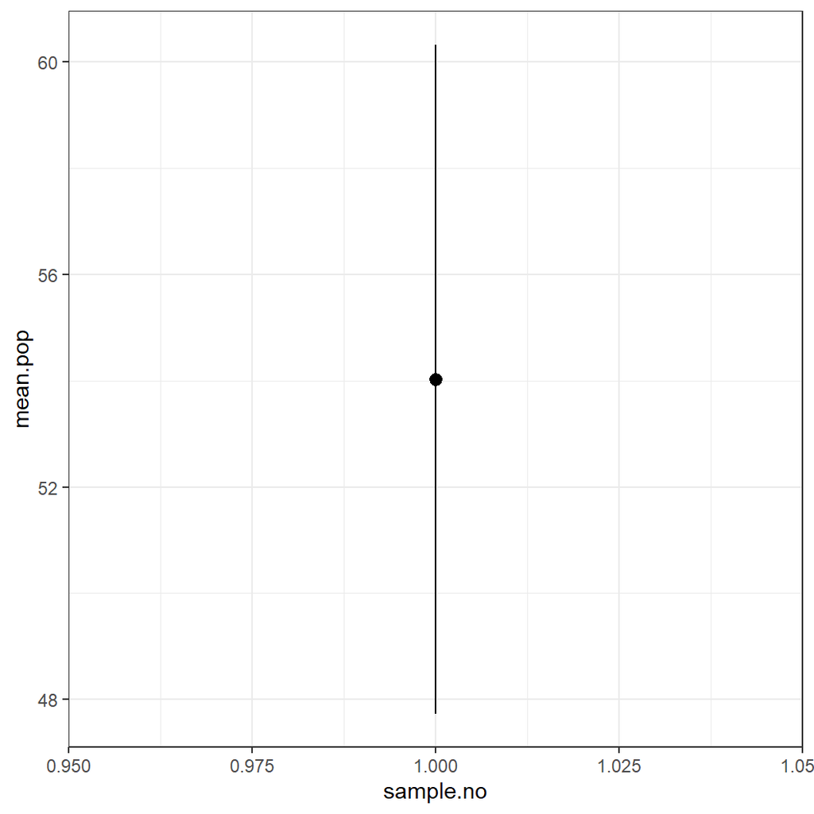

```r
## 평균 추정치와 신뢰구간을 그래프로 만들 수 있습니다.
estimates.df <- bind_rows(tibble(lower.pop,
                                 mean.pop,
                                 upper.pop))
estimates.df$sample.no <- 1

ggplot(data = estimates.df, aes(x = sample.no)) +
  geom_pointrange(aes(y = mean.pop,
                      ymin = lower.pop,
                      ymax = upper.pop))
```

```r
## 바로 만들 수도 있습니다.
estimates.df2 <- tibble(
  sample.no = 1,
  mean.pop = mean.pop,
  lower.pop = mean.pop - (1.96 * se.pop),
  upper.pop = mean.pop + (1.96 * se.pop)
)
estimates.df2
```

| sample.no | mean.pop | lower.pop | upper.pop |
| --- | --- | --- | --- |
| 1 | 54.0266 | 47.72967 | 60.32352 |

표본 1개의 평균값과 95% 신뢰구간의 경계값 (bound)을 표현한 그래프입니다.

동일한 작업을 루프를 이용하여 20개의 표본을 대상으로 하는 평균과 95% 신뢰구간의 하위/상위 경계값을 구해보겠습니다.

```r
mean.pop.20 <- rep(NA, 20)
lower.pop.20 <- rep(NA, 20)
upper.pop.20 <- rep(NA, 20)

for(x in 1:20) {
  samp.pop <- sample(WDI.data$SP.URB.TOTL.IN.ZS, 50)
  mean.pop.20[x] <- mean(samp.pop, na.rm = TRUE)
  lower.pop.20[x] <- mean.pop.20[x] -
    (1.96 * (sd(samp.pop, na.rm = TRUE)/sqrt(length(samp.pop))))
  upper.pop.20[x] <- mean.pop.20[x] +
    (1.96 * (sd(samp.pop, na.rm = TRUE)/sqrt(length(samp.pop))))
}
```

이렇게 구한 총 20개의 표본평균, 하위경계값, 상위경계값을 `estimates.df.20`이라는 데이터프레임에 저장하고 그래프로 나타내보겠습니다.

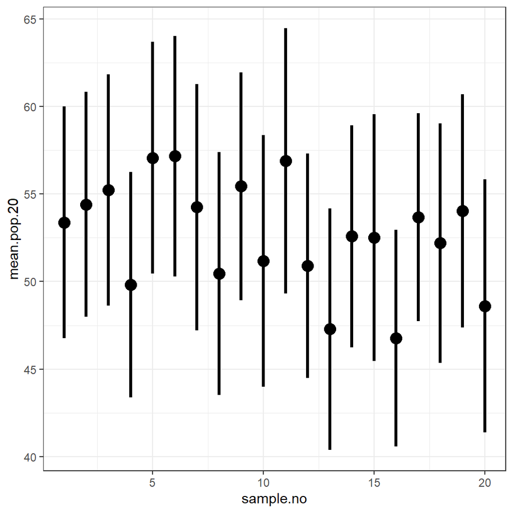

```r
estimates.df.20 <- tibble(lower.pop.20,
                          mean.pop.20,
                          upper.pop.20)
estimates.df.20$sample.no <- c(1:20)
ggplot(data = estimates.df.20, aes(x = sample.no,
                                   y = mean.pop.20)) +
  geom_point(size = 4) +
  geom_linerange(aes(ymin = lower.pop.20,
                      ymax = upper.pop.20),
                  size = 1.2)
```

사실 위와 같은 형태의 그래프를 제공하는 함수가 `coefplot()`이라고 따로 존재합니다. 요즘에는 회귀분석의 결과표만 보여주기 보다는 평균과 신뢰구간을 같이 보여줄 수 있는 회귀계수 그래프를 위와 같이 제시하는 추세입니다.

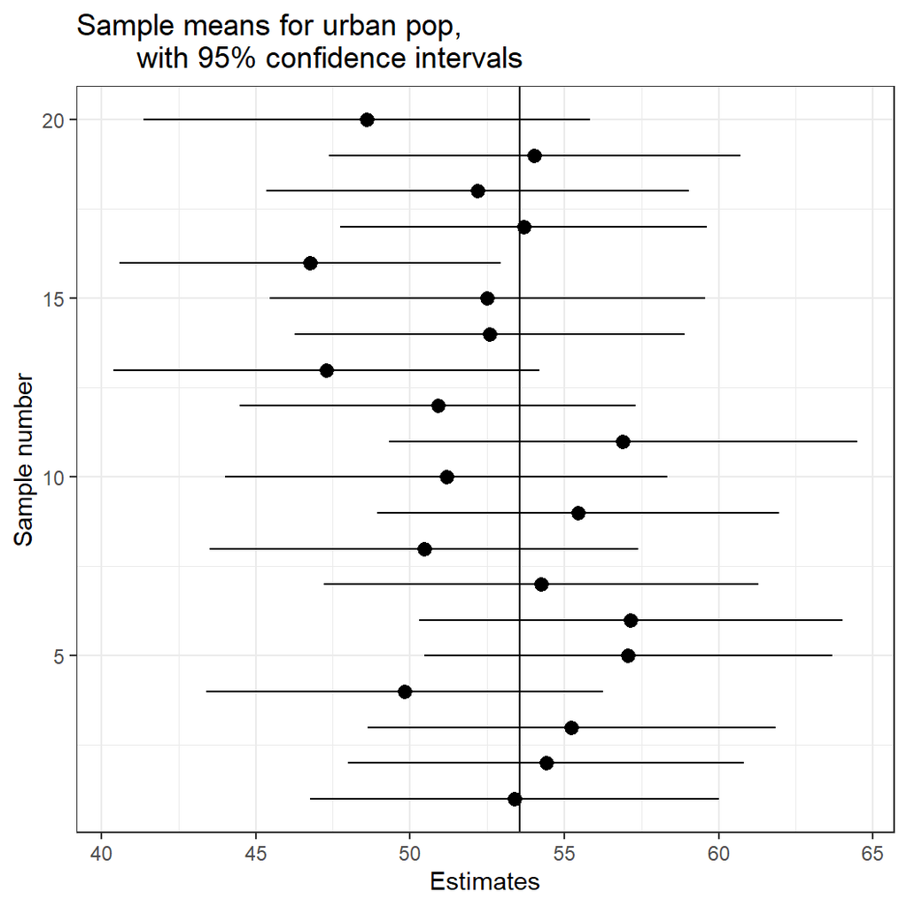

```r
ggplot(data = estimates.df.20,
       aes(x = sample.no, y = mean.pop.20)) +
  geom_pointrange(aes(ymin = lower.pop.20,
                      ymax = upper.pop.20)) +
  geom_hline(data = WDI.data,
             aes(yintercept =
                   mean(SP.URB.TOTL.IN.ZS,
                        na.rm = TRUE))) +
  coord_flip() +
  labs(x = "Sample number", y = "Estimates",
       title = "Sample means for urban pop,
       with 95% confidence intervals")
```

몇 가지 추가적인 특징들을 더 보여주기 위하여 한 가지 과정을 더해보았습니다. 먼저 95% 신뢰구간 밖에 존재하는 값들을 이탈치 (outliers)라고 할 때, 그 이탈치를 의미하는 더미변수를 하나 만들어보겠습니다. 이탈치면 1, 이탈치가 아니면 0의 값을 갖는 변수를 만들겠다는 것입니다. 95% 신뢰구간을 벗어났다는 것은 표본평균을 가지고 추론한 구간추정 범위 내에 모집단 평균이 존재하지 않는다는 것입니다.

```r
criteria <- mean(WDI.data$SP.URB.TOTL.IN.ZS, na.rm = TRUE)
estimates.df.20 <- estimates.df.20 %>%
  mutate(sig = ifelse(
    lower.pop.20 <= criteria &
      upper.pop.20 >= criteria, "Insig", "Sig"
  ) %>% parse_factor(., levels = c("Insig", "Sig"),
                     ordered = T, include_na = F))
```

마지막으로 표본평균 + 95% 신뢰구간이 모집단 평균을 포함하지 않는 경우에는 그래프 라인의 색을 빨간 색으로 바꾸는 코딩을 짜보겠습니다.

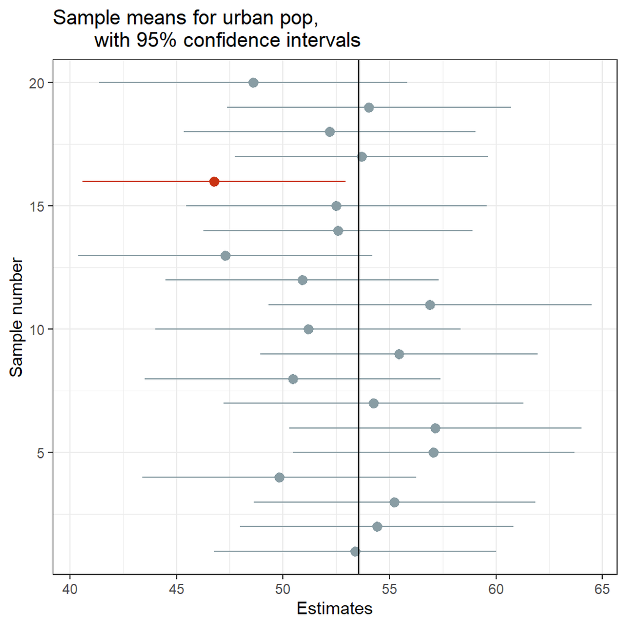

```r
ggplot(data = estimates.df.20,
       aes(x = sample.no, y = mean.pop.20,
           color = sig)) +
  geom_pointrange(aes(ymin = lower.pop.20,
                      ymax = upper.pop.20),
                  show.legend = F) +
  geom_hline(data = WDI.data,
             aes(yintercept =
                   mean(SP.URB.TOTL.IN.ZS,
                        na.rm = TRUE))) +
  coord_flip() +
  scale_color_manual(values =
                       wesanderson::wes_palette("Royal1")) +
  labs(x = "Sample number", y = "Estimates",
       title = "Sample means for urban pop,
       with 95% confidence intervals")
```

## 평균의 차이(difference of means)와 분산분석(analysis of variance, ANOVA)

사회과학, 정량적 사회과학 연구가 추구하는 목적 중 하나는 인과관계에 관한 추론, 인과추론(causal inference)입니다. 인과관계란 어떤 현상의 생성경로를 추적하기 위한 분석구도로서 경험적으로 확증될 수 없는 논리적 관계를 의미합니다.

인과관계의 성격은 유리스틱에 따라 달리 규정되지만, 생산(producing)의 관계라는 측면에서는 견해가 일치합니다. 즉, 원인이 기능하여 결과를 생산한다는 것이죠.

- 인과관계는 감각경험을 통해 인지할 수 있는 상호독립적 단위로 구성되며, 원인과 결과는 서로 다른 현상으로 일정한 기능적 연관성 이외에 어떠한 본질적 동질성도 공유하지 않는다고 봅니다.
- 또한 경험과학적 시각에서 모든 현상의 원인과 결과 사이의 인과관계는 규칙성과 재생성을 나타냅니다.
- 이 규칙성은 잠정적인 것으로 간주되는데, 그 이유는 네 가지 맥락에서 비롯됩니다.
1. 어떤 사회현상의 인과적 생성경로는 귀납적으로 추론되나, 귀납적 일반화는 귀납사례의 범주에 제한되어 조건적입니다.
2. 마찬가지로 밝혀진 원인들은 충분조건 또는 필요조건에 불과합니다.
3. 우리는 인과관계를 경험적으로 확인할 수는 없습니다.
4. 인간의 상호작용으로 나타나는 사회현상은 가변적이므로 그들 간 인과관계도 유동적입니다.

우리는 `X`와 `Y`의 관계를 논리적으로 설정할 수 있을 때, `X`를 원인으로, `Y`를 결과로 받아들여 양자 간 인과관계를 부여합니다.

- 단, 경험과학적 사회과학연구에서는 도출된 인과관계를 일단의 가정과 선행조건이 충족되었을 경우에 한해 성립되는 개연적 관계로 받아들입니다.
- 즉, 인과관계는 언제든 변할 수 있는 경향이나 추세라는 것입니다.

인과추론에 요구되는 근거는 크게 세 가지로 구분할 수 있습니다. 첫째 시간적 순차, 둘째 항상적 연계, 셋째, 탈허위성입니다.

- 시간적 순차(time-order)
  - 원인은 반드시 결과에 시간적으로 앞서야 합니다.
  - 시간차(time lag)의 경험적 근거가 필요하다.
- 항상적 연계
  - 어떤 현상(원인)의 변화가 다른 현상(결과)의 규칙적 변화를 지속적$\cdot$안정적으로 수반할 때, 이들 사이의 인과관계를 추론할 수 있습니다.
  - 실제 연구과정에 있어서 항상적 연계라는 논리적 척도는 통계적 공변(statistical covariance), 함수적 상관관계(functional correlation)라는 경험적 척도로 대체됩니다.
  - 예측변수와 종속변수 간의 공변규칙성이 연구의 시간적$\cdot$공간적 선행조건 하에서 안정적으로 나타날 때, 인과추론에 요구되는 경험적 근거를 얻을 수 있습니다.
  - 그러나 공변규칙성만으로 인과관계의 존재를 단정해서는 안 됩니다(관계는 경험적 관측 불가).
  - 단 항상적 연계는 인과관계의 필요조건입니다(항상적 연계 없으면 일단 인과관계도 없습니다).
- 탈허위성
  - 인과관계가 허위성을 가지지 않고 진정한(genuine) 것이어야 한다는 뜻입니다.

### 평균 차이를 보는 이유

앞에서 표집을 했을 때와 유사합니다. 사실 우리가 관측한 사회현상이 모집단 그 자체의 사회현상이라고 ‘결코’ 단언할 수 없습니다. 인과성(causality)에 대한 문제는, “어떠한 현상에 대한 원인은 무엇인가?”에 답을 하기 위함입니다. 이것이야말로 사회과학에서 가장 핵심이 라고 할 수 있습니다. 과학의 정수 는 이론의 수립이며, 이론은 인과적 진술이기 때문입니다. 현상에서 보이지 않는 법칙을 발견하고, 다듬어 나가는 것이 우리 사회“과학자”들이 하는 일이라고 할 수 있습니다. 때문에 인과성(causality)은 우리의 핵심 주제일 수밖에 없습니다.

인과효과(causal effect)는 다른 요인들이 통제되었을 때, 주요 변인들이 만들어내는 결과의 차이-영향이라고 할 수 있습니다. 예를 들어, 프랑스 혁명의 인과적 효과는 프랑스 혁명이 일어나지 않았을 때의 결과와 비교해볼 때 확인할 수 있습니다. 그런데 문제는 원인이 있을 때와 없을 때를 사회과학에서는 동시에 관찰할 수가 없다는 것입니다(반사실적 사례의 관측불가능성).

이 문제가 바로 인과추론의 근본적 문제입니다. 이 문제를 해결하기 위해 우리는 두 가지 가설적 방법들을 사용하게 됩니다. 사례를 들어보겠습니다. 가설로 “재직 중인 사람이 선거에서 득표율이 높을 것이다.”라고 할 때, 종속변인은 민주당원이 갖는 득표율이며, 이를 예측하기 위한 변인은 재직 여부가 될 것입니다. 그래서 재직 중인 사람이 나갔을 때 득표율과 새롭게 나간 사람의 득표율 을 비교, 그 사이의 차이가 바로 인과 효과라고 할 수 있을 것입니다. 예측변인을 제외 한 나머지는 통제되어야 합니다—즉, 변하지 않도록 해야 한다는 것(holding constant)입니다. 이러한 통제의 대상을 어떻게 선정할 것인가는 연구를 설계하는 연구자의 역량에 따라 좌우됩니다.

위 사례에서 반사실적 조건문(counterfactuals)을 통해 우리가 얻어낼 수 있는 것이 실현된 인과 효과(realized causal effect)입니다. 사회과학 연구방법론에 있어서 교과서적으로 읽히는 King, Keohane, 그리고 Verba의 1994년 저작 “Designing Social Inquiry”, 이하 KKV는 이 문제에 대해 우리는 관측가능한 효과에서 체계적인 것과 비체계적인 것을 구분해야 한다고 강조합니다.[^1] KKV는 우리가 체계적인 변화에 주목해야 한다고 주장합니다. 그리고 그것을 위해서 우리는 가설적인 반복을 통해 비체계적 요인들을 상쇄시키고, 체계적인 요인들만의 영향—평균적인 인과 효과를 살펴볼 수 있다는 것입니다.

사실, 우리는 우리가 관찰하는 대상 안에 오차(error)가 존재한다고 생각할 수밖에 없기 때문에, 그것을 최소화시키는(maximizing error term) 것이야말로 체계적인 변화의 요인을 추적할 수 있는 방법이 될 수 있습니다. 가설적 반복을 통해 나오는 하나의 분석단위에 대한 확률적인 인과 효과를 평균적으로 보는 것(Random Causal Effect for $\text{unit}_i$), 즉 평균적 인과 효과(Mean causal effect)는 체계적인 요인들이 가지고 오는 영향의 평균을 의미합니다. KKV는 이와 같이 관측된 인과 효과에서 체계적-비체계적 효과를 구분하는 것을 포함하여 인과 효과의 논의를 발전시켰습니다.

여기서 하나 더 살펴보아야 하는 것이 바로 분산입니다. 분산이란 실제로 관측된 데이터들이 평균에서 어느 정도 수준으로 흩어져 있는지를 보여주는 통계치입니다. 즉, 관측된 사회현상은 필연적으로 일정한 수준의 분산을 가지게 되는데, 이 변수 자체 분산을 고려하여, 우리가 보고자 하는 두 변수의 관계에 적용할 수 있습니다. 간단히 정리하자면, 두 변수의 평균의 차이가 두 변수의 분산 정도를 무시할 수 있을 정도로 명확하다면, 우리는 통계적으로 이 두 변수 간의 차이가 유의미하다고 볼 수 있습니다. 이에 관한 내용은 추후에 더 자세히 살펴볼 기회가 있을 것입니다.

일단 여기까지가 바로 우리가 인과추론을 이해하기 위한 기초로서 평균 차 분석의 논리를 살펴보아야 하는 이유입니다. 이론적 논의는 여기까지하고, **R**을 통해 실제 자료를 바탕으로 예제를 통해 구체적인 논의를 이끌어 나가보도록 하겠습니다. 오픈소스로 공개되어 있는 정부의 질(Quality of Government, 이햐 QoG) 데이터셋의 교차사례 자료(cross-section data)를 사용해보겠습니다.

```r
library(ezpickr)
QOG <- pick(file = "http://www.qogdata.pol.gu.se/data/qog_bas_ts_jan20.dta")
# 2010년도 자료만 보겠습니다.
QOG <- QOG %>% dplyr::filter(year == 2010)
```